# Tổng quan về Pandas

## 1. Giới thiệu (Introduction)

- **pandas** là một thư viện trong python hỗ trợ tốt trong việc thao tác dữ liệu. Thư viện này sử dụng một cấu trúc dữ liệu riêng là Dataframe.
- Thông tin tổng quát trên [trang](https://pandas.pydata.org/about/index.html) của pandas.
- Ưu điểm khi sử dụng của Pandas:
  - Có thể xử lý tập dữ liệu khác nhau về định dạng: chuỗi thời gian, bảng không đồng nhất, ma trận dữ liệu
  - Khả năng thao tác dữ liệu từ nhiều bộ nhớ và định dạng file: csv,text, excel, sql, database, hdf5
  - Liên kết dữ liệu thông minh, xử lý được trường hợp dữ liệu bị thiếu.
  - Tối ưu về hiệu năng

## 2.Cài đặt (Install):

- Cài đặt môi trường để làm việc, sau đó install thư viện pandas bằng câu lệnh:

  > $ pip install pandas
- Kiểm tra thư viện pandas trong môi trường:

  > $ conda list

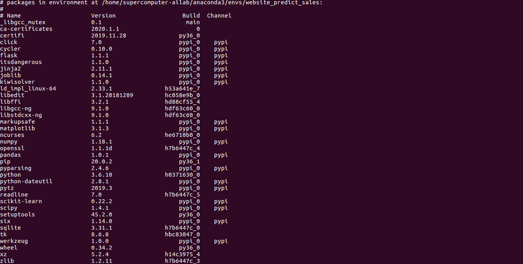

## 3. Một số ví dụ về hàm trong pandas (Example of pandas functions):

```
- Việc đầu tiên ta cần import thư viện vào dự án
```

```python
import pandas as pd
```

3.1. Đọc file dữ liệu

- Tham khảo tham số của [hàm](https://bom.to/y06TnU/)
- Lưu ý:
  - Đường dẫn file dữ liệu cần đọc
  - Về tham số
    - *endcodeing*: chỉ định encoding của file đọc vào. Mặc định là utf-8
    - *sep*: thay đổi dấu ngăn cách giữa các cột. Mặc định là dấu phẩy (‘,’)
    - *header*: chỉ định file đọc vào có header(tiêu đề của các cột) hay không. Mặc định là infer
    - **_index*col***: chỉ định chỉ số cột nào là cột chỉ số(số thứ tự). Mặc định là None
    - *nrows* chỉ định số bản ghi sẽ đọc vào. Mặc định là None – đọc toàn bộ
- Ví dụ đọc file csv:

```python
house_data_df = pd.read_csv('./sup/data/house_data.csv')
```

3.2. In ra bản dữ liệu của dataframe với n số lượng phần tử đầu tiên ta dùng hàm **.head()** ngược lại là hàm **.tail()**

- Tham khảo tham số của hàm head hoặc hàm tail
- Ví dụ về sử dụng hàm head:

```python
house_data_df.head(5)
```

|  | Id | MSSubClass | MSZoning | LotFrontage | LotArea | Street | Alley | LotShape | LandContour | Utilities | ... | ScreenPorch | PoolArea | PoolQC | Fence | MiscFeature | MiscVal | MoSold | YrSold | SaleType | SaleCondition |
| --- | --- | --- | --- | --- | --- | --- | --- | --- | --- | --- | --- | --- | --- | --- | --- | --- | --- | --- | --- | --- | --- |
| 0 | 1461 | 20 | RH | 80.0 | 11622 | Pave | NaN | Reg | Lvl | AllPub | ... | 120 | 0 | NaN | MnPrv | NaN | 0 | 6 | 2010 | WD | Normal |
| 1 | 1462 | 20 | RL | 81.0 | 14267 | Pave | NaN | IR1 | Lvl | AllPub | ... | 0 | 0 | NaN | NaN | Gar2 | 12500 | 6 | 2010 | WD | Normal |
| 2 | 1463 | 60 | RL | 74.0 | 13830 | Pave | NaN | IR1 | Lvl | AllPub | ... | 0 | 0 | NaN | MnPrv | NaN | 0 | 3 | 2010 | WD | Normal |
| 3 | 1464 | 60 | RL | 78.0 | 9978 | Pave | NaN | IR1 | Lvl | AllPub | ... | 0 | 0 | NaN | NaN | NaN | 0 | 6 | 2010 | WD | Normal |
| 4 | 1465 | 120 | RL | 43.0 | 5005 | Pave | NaN | IR1 | HLS | AllPub | ... | 144 | 0 | NaN | NaN | NaN | 0 | 1 | 2010 | WD | Normal |

5 rows × 80 columns

3.3. Lấy thông tin dữ liệu của dataframe với hàm **.info()** và xem kích thước dữ liệu với hàm **.shape**

- Tham khảo về hàm info hoặc hàm shape
- Ví dụ về sử dụng hàm info:

```python
house_data_df.info()
```

```
<class 'pandas.core.frame.DataFrame'>
RangeIndex: 1459 entries, 0 to 1458
Data columns (total 80 columns):
Id               1459 non-null int64
MSSubClass       1459 non-null int64
MSZoning         1455 non-null object
LotFrontage      1232 non-null float64
LotArea          1459 non-null int64
Street           1459 non-null object
Alley            107 non-null object
LotShape         1459 non-null object
LandContour      1459 non-null object
Utilities        1457 non-null object
LotConfig        1459 non-null object
LandSlope        1459 non-null object
Neighborhood     1459 non-null object
Condition1       1459 non-null object
Condition2       1459 non-null object
BldgType         1459 non-null object
HouseStyle       1459 non-null object
OverallQual      1459 non-null int64
OverallCond      1459 non-null int64
YearBuilt        1459 non-null int64
YearRemodAdd     1459 non-null int64
RoofStyle        1459 non-null object
RoofMatl         1459 non-null object
Exterior1st      1458 non-null object
Exterior2nd      1458 non-null object
MasVnrType       1443 non-null object
MasVnrArea       1444 non-null float64
ExterQual        1459 non-null object
ExterCond        1459 non-null object
Foundation       1459 non-null object
BsmtQual         1415 non-null object
BsmtCond         1414 non-null object
BsmtExposure     1415 non-null object
BsmtFinType1     1417 non-null object
BsmtFinSF1       1458 non-null float64
BsmtFinType2     1417 non-null object
BsmtFinSF2       1458 non-null float64
```

[output cut: 30 more lines]

```
OpenPorchSF      1459 non-null int64
EnclosedPorch    1459 non-null int64
3SsnPorch        1459 non-null int64
ScreenPorch      1459 non-null int64
PoolArea         1459 non-null int64
PoolQC           3 non-null object
Fence            290 non-null object
MiscFeature      51 non-null object
MiscVal          1459 non-null int64
MoSold           1459 non-null int64
YrSold           1459 non-null int64
SaleType         1458 non-null object
SaleCondition    1459 non-null object
dtypes: float64(11), int64(26), object(43)
memory usage: 912.0+ KB
```

- Ví dụ về hàm shape:

```python
house_data_df.shape
```

```
(1459, 80)
```

3.4. Lấy giá trị

- Ta sẽ truyền vào thông tên các cột để lấy ra thông tin của các cột đó
- Ví dụ về lấy ra thông tin của 5 hàng cuối với hai cột **Id** và **Street**:

```python
house_data_df[['Id','Street']].tail(5)
```

|  | Id | Street |
| --- | --- | --- |
| 1454 | 2915 | Pave |
| 1455 | 2916 | Pave |
| 1456 | 2917 | Pave |
| 1457 | 2918 | Pave |
| 1458 | 2919 | Pave |

- Lấy bản ghi có điều kiện ta sẽ tìm bản ghi phù hợp điều kiện của cột đó
- Tham khảo hướng dẫn [tại đây](https://thispointer.com/python-pandas-select-rows-in-dataframe-by-conditions-on-multiple-columns/)
- Ví dụ về lấy bản ghi có điều kiện **Id** nằm trong đoạn từ 1500 đến 1510:

```python
dt_df_fr_1500_1510 = house_data_df[(house_data_df['Id']>=1500) & (house_data_df['Id']<=1510)]
dt_df_fr_1500_1510
```

|  | Id | MSSubClass | MSZoning | LotFrontage | LotArea | Street | Alley | LotShape | LandContour | Utilities | ... | ScreenPorch | PoolArea | PoolQC | Fence | MiscFeature | MiscVal | MoSold | YrSold | SaleType | SaleCondition |
| --- | --- | --- | --- | --- | --- | --- | --- | --- | --- | --- | --- | --- | --- | --- | --- | --- | --- | --- | --- | --- | --- |
| 39 | 1500 | 160 | FV | 24.0 | 2544 | Pave | Pave | Reg | Lvl | AllPub | ... | 0 | 0 | NaN | NaN | NaN | 0 | 5 | 2010 | WD | Normal |
| 40 | 1501 | 160 | FV | NaN | 2980 | Pave | NaN | Reg | Lvl | AllPub | ... | 0 | 0 | NaN | NaN | NaN | 0 | 5 | 2010 | WD | Normal |
| 41 | 1502 | 160 | FV | NaN | 2403 | Pave | NaN | IR1 | Lvl | AllPub | ... | 0 | 0 | NaN | NaN | NaN | 0 | 6 | 2010 | WD | Normal |
| 42 | 1503 | 20 | FV | 57.0 | 12853 | Pave | Pave | IR1 | Lvl | AllPub | ... | 0 | 0 | NaN | NaN | NaN | 0 | 4 | 2010 | New | Partial |
| 43 | 1504 | 60 | FV | 68.0 | 7379 | Pave | NaN | IR1 | Lvl | AllPub | ... | 0 | 0 | NaN | NaN | NaN | 0 | 4 | 2010 | WD | Normal |
| 44 | 1505 | 20 | FV | 80.0 | 8000 | Pave | NaN | Reg | Lvl | AllPub | ... | 0 | 0 | NaN | NaN | NaN | 0 | 4 | 2010 | WD | Normal |
| 45 | 1506 | 20 | RL | NaN | 10456 | Pave | NaN | IR1 | Lvl | AllPub | ... | 0 | 0 | NaN | NaN | NaN | 0 | 5 | 2010 | WD | Normal |
| 46 | 1507 | 60 | RL | 80.0 | 10791 | Pave | NaN | Reg | Lvl | AllPub | ... | 0 | 0 | NaN | NaN | NaN | 0 | 3 | 2010 | WD | Normal |
| 47 | 1508 | 50 | RL | NaN | 18837 | Pave | NaN | IR1 | Lvl | AllPub | ... | 0 | 0 | NaN | NaN | NaN | 0 | 4 | 2010 | WD | Normal |
| 48 | 1509 | 60 | RL | 80.0 | 9600 | Pave | NaN | Reg | Lvl | AllPub | ... | 0 | 0 | NaN | GdWo | NaN | 0 | 6 | 2010 | WD | Normal |
| 49 | 1510 | 20 | RL | 80.0 | 9600 | Pave | NaN | Reg | Lvl | AllPub | ... | 0 | 0 | NaN | NaN | NaN | 0 | 4 | 2010 | WD | Normal |

11 rows × 80 columns

3.5. Thay đổi dữ liệu

- Thêm cột mới có giá
  - Tham khảo [tại đây](https://pandas.pydata.org/pandas-docs/stable/reference/api/pandas.DataFrame.append.html)
  - Ví dụ thêm cột mới có giá trị rỗng

```python
dt_df_fr_1500_1510 =  dt_df_fr_1500_1510[['Id','LotShape','Street']]
dt_df_fr_1500_1510
```

|  | Id | LotShape | Street |
| --- | --- | --- | --- |
| 39 | 1500 | Reg | Pave |
| 40 | 1501 | Reg | Pave |
| 41 | 1502 | IR1 | Pave |
| 42 | 1503 | IR1 | Pave |
| 43 | 1504 | IR1 | Pave |
| 44 | 1505 | Reg | Pave |
| 45 | 1506 | IR1 | Pave |
| 46 | 1507 | Reg | Pave |
| 47 | 1508 | IR1 | Pave |
| 48 | 1509 | Reg | Pave |
| 49 | 1510 | Reg | Pave |

```python
dt_df_fr_1500_1510['n_column'] = None
dt_df_fr_1500_1510
```

|  | Id | LotShape | Street | n_column |
| --- | --- | --- | --- | --- |
| 39 | 1500 | Reg | Pave | None |
| 40 | 1501 | Reg | Pave | None |
| 41 | 1502 | IR1 | Pave | None |
| 42 | 1503 | IR1 | Pave | None |
| 43 | 1504 | IR1 | Pave | None |
| 44 | 1505 | Reg | Pave | None |
| 45 | 1506 | IR1 | Pave | None |
| 46 | 1507 | Reg | Pave | None |
| 47 | 1508 | IR1 | Pave | None |
| 48 | 1509 | Reg | Pave | None |
| 49 | 1510 | Reg | Pave | None |

- Sửa giá trị tại cột
  - Ví dụ sửa giá trị tại cột **n_column** từ **Id** 1500 đến 1505

```python
dt_df_fr_1500_1505 = dt_df_fr_1500_1510[(dt_df_fr_1500_1510['Id']<=1505)]
dt_df_fr_1500_1505['n_column']= dt_df_fr_1500_1505['LotShape']=='Reg'
dt_df_fr_1500_1505
```

|  | Id | LotShape | Street | n_column |
| --- | --- | --- | --- | --- |
| 39 | 1500 | Reg | Pave | True |
| 40 | 1501 | Reg | Pave | True |
| 41 | 1502 | IR1 | Pave | False |
| 42 | 1503 | IR1 | Pave | False |
| 43 | 1504 | IR1 | Pave | False |
| 44 | 1505 | Reg | Pave | True |

- Sắp xếp dữ liệu:
  - Tham khảo [tại đây](https://pandas.pydata.org/docs/reference/api/pandas.DataFrame.sort_values.html?highlight=sort_value)
  - Ví dụ về sắp xếp:

```python
sort_dt_df_fr_1500_1505 = dt_df_fr_1500_1505.sort_values('LotShape',ascending=True)
sort_dt_df_fr_1500_1505
```

|  | Id | LotShape | Street | n_column |
| --- | --- | --- | --- | --- |
| 41 | 1502 | IR1 | Pave | False |
| 42 | 1503 | IR1 | Pave | False |
| 43 | 1504 | IR1 | Pave | False |
| 39 | 1500 | Reg | Pave | True |
| 40 | 1501 | Reg | Pave | True |
| 44 | 1505 | Reg | Pave | True |

- Nối hai dataframe với nhau:
  - Tham khảo [tại đây](https://pandas.pydata.org/docs/reference/api/pandas.DataFrame.append.html?highlight=append#pandas.DataFrame.append)
  - Ví dụ:

```python
dt_df_fr_1480_1485 = house_data_df[(house_data_df['Id']>=1480) & (house_data_df['Id']<=1485)]
dt_df_fr_1480_1485 = dt_df_fr_1480_1485[['Id','LotShape','Street']]
dt_df_fr_1480_1485
```

|  | Id | LotShape | Street |
| --- | --- | --- | --- |
| 19 | 1480 | Reg | Pave |
| 20 | 1481 | Reg | Pave |
| 21 | 1482 | IR1 | Pave |
| 22 | 1483 | IR1 | Pave |
| 23 | 1484 | Reg | Pave |
| 24 | 1485 | IR1 | Pave |

```python
new_dt_df_ap = dt_df_fr_1480_1485.append(dt_df_fr_1500_1510, sort=False)
new_dt_df_ap
```

|  | Id | LotShape | Street | n_column |
| --- | --- | --- | --- | --- |
| 19 | 1480 | Reg | Pave | NaN |
| 20 | 1481 | Reg | Pave | NaN |
| 21 | 1482 | IR1 | Pave | NaN |
| 22 | 1483 | IR1 | Pave | NaN |
| 23 | 1484 | Reg | Pave | NaN |
| 24 | 1485 | IR1 | Pave | NaN |
| 39 | 1500 | Reg | Pave | None |
| 40 | 1501 | Reg | Pave | None |
| 41 | 1502 | IR1 | Pave | None |
| 42 | 1503 | IR1 | Pave | None |
| 43 | 1504 | IR1 | Pave | None |
| 44 | 1505 | Reg | Pave | None |
| 45 | 1506 | IR1 | Pave | None |
| 46 | 1507 | Reg | Pave | None |
| 47 | 1508 | IR1 | Pave | None |
| 48 | 1509 | Reg | Pave | None |
| 49 | 1510 | Reg | Pave | None |

3.6. Lưu xuống file csv mới

- Tham khảo [tại đây](https://pandas.pydata.org/docs/reference/api/pandas.DataFrame.to_csv.html?highlight=to_csv#pandas.DataFrame.to_csv)
- Ví dụ:

```python
new_dt_df_ap.to_csv('./sup/data/data_new')
```

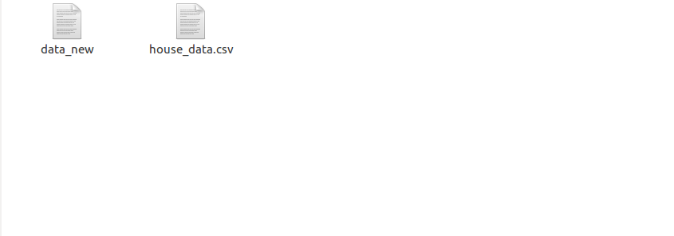

## 4. Nguồn tham khảo (Reference source):

1. Hướng dẫn về sử dụng pandas tiếng Việt [link1](https://labs.septeni-technology.jp/category/pandas/) | [link2](https://nguyenvanhieu.vn/thu-vien-pandas-python/).
2. [Trang Chủ](https://pandas.pydata.org/) pandas.
3. Các bạn có thể yêu cầu chỉnh sửa hoặc đóng góp thêm cho bài làm hoàn thiện hơn qua: dtphong010199@gmail.com